# Rmd documents

Dillon Niederhut

February 3, 2015

# This is a level 1 heading

## This is a level 2 heading

### This is a level 3 heading

## You can have plain text

1. As a numbered list
2. That goes on
3. As long as you like
- Or as a bulleted list
  - With sublists

Or a link that will open separately in a web browser

Or just plain text with *italics*, **boldface**, <sub>subscript</sub>, <sup>superscript</sup>, and strikethrough

## You can have code

Inline code is created by putting a `single back tick` on each end of the code

```
Code blocks are created with three back ticks above and below
```

Note that, as written, these will not actually run anything

## You can have a picture

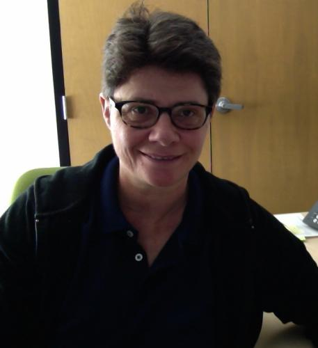

The image source can be local or remote, but Rmd does not currently allow you to resize

## You can have a table

| Table Name | Col 1 Name | Col 2 Name |
| --- | --- | --- |
| Row 1 Name | (1,1) | (1,2) |
| Row 2 Name | (2,1) | (2,2) |

This will still format correctly even if you don’t add the extra whitespace to make everything line up - they’re only there to make it more human readable. If you don’t want to have a table name, you’ll need to bracket the left and right sides of each row with | like this:

|  | Col 1 Name | Col 2 Name |
| --- | --- | --- |
| Row 1 Name | (1,1) | (1,2) |
| Row 2 Name | (2,1) | (2,2) |

## Within a slide, you can echo and evaluate code

```r
model <- lm(dist ~ speed, data = cars)
summary(model)
```

```
##
## Call:
## lm(formula = dist ~ speed, data = cars)
##
## Residuals:
##    Min     1Q Median     3Q    Max
## -29.07  -9.53  -2.27   9.21  43.20
##
## Coefficients:
##             Estimate Std. Error t value Pr(>|t|)
## (Intercept)  -17.579      6.758   -2.60    0.012 *
## speed          3.932      0.416    9.46  1.5e-12 ***
## ---
## Signif. codes:  0 '***' 0.001 '**' 0.01 '*' 0.05 '.' 0.1 ' ' 1
##
## Residual standard error: 15.4 on 48 degrees of freedom
## Multiple R-squared:  0.651,  Adjusted R-squared:  0.644
## F-statistic: 89.6 on 1 and 48 DF,  p-value: 1.49e-12
```

Keep in mind that not only will this echo your code, but also anything else that would normally appear in the console, like warnings and messages

## Within a slide, you can create a plot

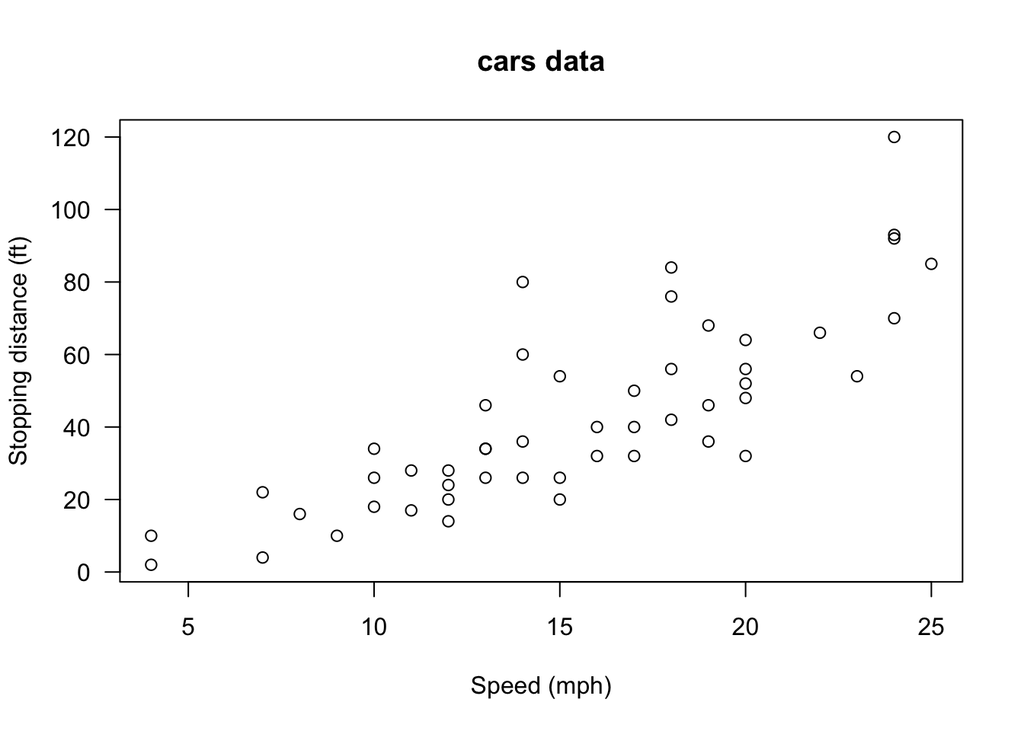

This will not echo code nor warnings, but only direct dev ouput normally used by plotting functions like plot() and ggplot() to the markup engine.

## For more information, see

[Reference Guide](http://rmarkdown.rstudio.com/RMarkdownReferenceGuide.pdf)